# Atividade avaliativa -2

**10. This question should be answered using the Weekly data set, which is part of the ISLR package. This data is similar in nature to the Smarket data from this chapter’s lab, except that it contains 1089 Weekly returns for 21 years, from the beginning of 1990 to the end of 2010.**

**(a) Produce some numerical and graphical summaries of the Weekly data. Do there appear to be any patterns?**

```r
library(tidyverse)
library(ISLR)
data("Weekly")
summary(Weekly)
```

```
      Year           Lag1               Lag2               Lag3               Lag4               Lag5
 Min.   :1990   Min.   :-18.1950   Min.   :-18.1950   Min.   :-18.1950   Min.   :-18.1950   Min.   :-18.1950
 1st Qu.:1995   1st Qu.: -1.1540   1st Qu.: -1.1540   1st Qu.: -1.1580   1st Qu.: -1.1580   1st Qu.: -1.1660
 Median :2000   Median :  0.2410   Median :  0.2410   Median :  0.2410   Median :  0.2380   Median :  0.2340
 Mean   :2000   Mean   :  0.1506   Mean   :  0.1511   Mean   :  0.1472   Mean   :  0.1458   Mean   :  0.1399
 3rd Qu.:2005   3rd Qu.:  1.4050   3rd Qu.:  1.4090   3rd Qu.:  1.4090   3rd Qu.:  1.4090   3rd Qu.:  1.4050
 Max.   :2010   Max.   : 12.0260   Max.   : 12.0260   Max.   : 12.0260   Max.   : 12.0260   Max.   : 12.0260
     Volume            Today          Direction
 Min.   :0.08747   Min.   :-18.1950   Down:484
 1st Qu.:0.33202   1st Qu.: -1.1540   Up  :605
 Median :1.00268   Median :  0.2410
 Mean   :1.57462   Mean   :  0.1499
 3rd Qu.:2.05373   3rd Qu.:  1.4050
 Max.   :9.32821   Max.   : 12.0260
```

There is one categorical feature and all other features are numerical

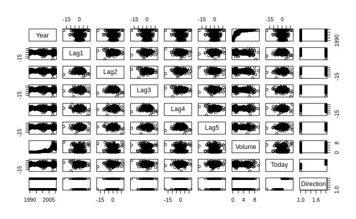

```r
plot(Weekly)
```

The scatter plot of the Weekly data indicates all the Lag variables are weakly correlated to each other. From the scatter plot, it can also be noted that the volumes of shares traded is rapidly increasing., year by year.

```r
cor(Weekly[,-9])
```

```
              Year         Lag1        Lag2        Lag3         Lag4         Lag5      Volume        Today
Year    1.00000000 -0.032289274 -0.03339001 -0.03000649 -0.031127923 -0.030519101  0.84194162 -0.032459894
Lag1   -0.03228927  1.000000000 -0.07485305  0.05863568 -0.071273876 -0.008183096 -0.06495131 -0.075031842
Lag2   -0.03339001 -0.074853051  1.00000000 -0.07572091  0.058381535 -0.072499482 -0.08551314  0.059166717
Lag3   -0.03000649  0.058635682 -0.07572091  1.00000000 -0.075395865  0.060657175 -0.06928771 -0.071243639
Lag4   -0.03112792 -0.071273876  0.05838153 -0.07539587  1.000000000 -0.075675027 -0.06107462 -0.007825873
Lag5   -0.03051910 -0.008183096 -0.07249948  0.06065717 -0.075675027  1.000000000 -0.05851741  0.011012698
Volume  0.84194162 -0.064951313 -0.08551314 -0.06928771 -0.061074617 -0.058517414  1.00000000 -0.033077783
Today  -0.03245989 -0.075031842  0.05916672 -0.07124364 -0.007825873  0.011012698 -0.03307778  1.000000000
```

There is a strong correlation between Year and Volume, all the others have a weak correlation.

**(b) Use the full data set to perform a logistic regression with Direction as the response and the five lag variables plus Volume as predictors. Use the summary function to print the results. Do any of the predictors appear to be statistically significant? If so, which ones?**

```r
reg1 <- glm(Direction~.-Year-Today,data=Weekly,family="binomial")
summary(reg1)
```

```
Call:
glm(formula = Direction ~ . - Year - Today, family = "binomial",
    data = Weekly)

Deviance Residuals:
    Min       1Q   Median       3Q      Max
-1.6949  -1.2565   0.9913   1.0849   1.4579

Coefficients:
            Estimate Std. Error z value Pr(>|z|)
(Intercept)  0.26686    0.08593   3.106   0.0019 **
Lag1        -0.04127    0.02641  -1.563   0.1181
Lag2         0.05844    0.02686   2.175   0.0296 *
Lag3        -0.01606    0.02666  -0.602   0.5469
Lag4        -0.02779    0.02646  -1.050   0.2937
Lag5        -0.01447    0.02638  -0.549   0.5833
Volume      -0.02274    0.03690  -0.616   0.5377
---
Signif. codes:  0 ‘***’ 0.001 ‘**’ 0.01 ‘*’ 0.05 ‘.’ 0.1 ‘ ’ 1

(Dispersion parameter for binomial family taken to be 1)

    Null deviance: 1496.2  on 1088  degrees of freedom
Residual deviance: 1486.4  on 1082  degrees of freedom
AIC: 1500.4

Number of Fisher Scoring iterations: 4
```

**(c) Compute the confusion matrix and overall fraction of correct predictions. Explain what the confusion matrix is telling you about the types of mistakes made by logistic regression.**

```r
glm.proba <- predict(reg1,type = "response")
glm.pred <- rep("Down",nrow(Weekly))
glm.pred[glm.proba>0.5] = "Up"
table(glm.pred,Weekly$Direction)
```

```
glm.pred Down  Up
    Down   54  48
    Up    430 557
```

```r
mean(glm.pred == Weekly$Direction)
```

```
[1] 0.5610652
```

```r
557/(557+48)
```

```
[1] 0.9206612
```

```r
54/(430+54)
```

```
[1] 0.1115702
```

We can be observed that the algorithm classifies about 56% of the observations correctly. It also performs well on the days that the stock increases, since about 92% of ‘Up’ entries are correctly classified. However, it performs poorly on days the market is down, with about 11% of these cases classified correctly.

**(d) Now fit the logistic regression model using a training data period from 1990 to 2008, with Lag2 as the only predictor. Compute the confusion matrix and the overall fraction of correct predictions for the held out data (that is, the data from 2009 and 2010).**

```r
train <- Weekly[,"Year"] <= 2008
glm.fit <- glm(Direction~Lag2,data = Weekly,subset = train, family = "binomial")
summary(glm.fit)
```

```
Call:
glm(formula = Direction ~ Lag2, family = "binomial", data = Weekly,
    subset = train)

Deviance Residuals:
   Min      1Q  Median      3Q     Max
-1.536  -1.264   1.021   1.091   1.368

Coefficients:
            Estimate Std. Error z value Pr(>|z|)
(Intercept)  0.20326    0.06428   3.162  0.00157 **
Lag2         0.05810    0.02870   2.024  0.04298 *
---
Signif. codes:  0 ‘***’ 0.001 ‘**’ 0.01 ‘*’ 0.05 ‘.’ 0.1 ‘ ’ 1

(Dispersion parameter for binomial family taken to be 1)

    Null deviance: 1354.7  on 984  degrees of freedom
Residual deviance: 1350.5  on 983  degrees of freedom
AIC: 1354.5

Number of Fisher Scoring iterations: 4
```

```r
glm.probs <- predict(glm.fit,Weekly[!train,],type = "response")
glm.pred <- rep("Down",nrow(Weekly))
glm.pred[glm.probs>0.5] = "Up"
table(glm.pred,Weekly[,"Direction"])
```

```
glm.pred Down  Up
    Down   63  85
    Up    421 520
```

```r
mean(glm.pred == Weekly[,"Direction"])
```

```
[1] 0.5353535
```

**(e) Repeat (d) using LDA.**

```r
library(MASS)
#Weekly2 <- read.csv()
lda.fit <- lda(Direction~Lag2,data=Weekly,subset=train)
lda.fit
```

```
Call:
lda(Direction ~ Lag2, data = Weekly, subset = train)

Prior probabilities of groups:
     Down        Up
0.4477157 0.5522843

Group means:
            Lag2
Down -0.03568254
Up    0.26036581

Coefficients of linear discriminants:
           LD1
Lag2 0.4414162
```

```r
lda.pred <- predict(lda.fit,Weekly[!train,])
lda.class <- lda.pred$class
table(lda.class,Weekly[!train,9])
```

```
lda.class Down Up
     Down    9  5
     Up     34 56
```

```r
mean(lda.class == Weekly[!train,9])
```

```
[1] 0.625
```

** (f) Repeat (d) using QDA. **

```r
qda.fit <- qda(Direction~Lag2,data=Weekly,subset=train)
qda.fit
```

```
Call:
qda(Direction ~ Lag2, data = Weekly, subset = train)

Prior probabilities of groups:
     Down        Up
0.4477157 0.5522843

Group means:
            Lag2
Down -0.03568254
Up    0.26036581
```

```r
qda.pred <- predict(qda.fit,Weekly[!train,])
qda.class <- qda.pred$class
table(qda.class,Weekly[!train,9])
```

```
qda.class Down Up
     Down    0  0
     Up     43 61
```

```r
mean(qda.class == Weekly[!train,9])
```

```
[1] 0.5865385
```

**(h) Which of these methods appears to provide the best results on this data?**

LDA because of the higher prediction accuracy

**11. In this problem, you will develop a model to predict whether a given car gets high or low gas mileage based on the Auto data set.**

**(a) Create a binary variable, mpg01 , that contains a 1 if mpg contains a value above its median, and a 0 if mpg contains a value below its median. You can compute the median using the median() function. Note you may find it helpful to use the data.frame() function to create a single data set containing both mpg01 and the other Auto variables.**

```r
mpg01 <- rep(0,nrow(Auto))
mpg01[Auto[,'mpg']>median(Auto[,'mpg'])] <- 1
mpg01 = as.factor(mpg01)
Data = data.frame(Auto,mpg01)
table(mpg01)
```

```
mpg01
  0   1
196 196
```

**(b) Explore the data graphically in order to investigate the associ- ation between mpg01 and the other features. Which of the other features seem most likely to be useful in predicting mpg01 ? Scatterplots and boxplots may be useful tools to answer this question. Describe your findings.**

```r
par(mfrow = c(2,2))
boxplot(acceleration~mpg01,Data,main="Accel~mpg01")
boxplot(weight~mpg01,Data,main="Weight~mpg01")
```

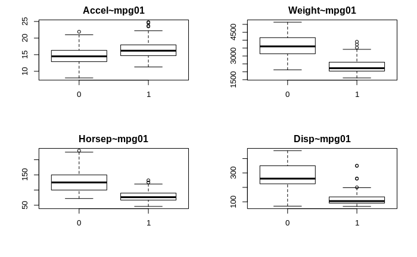

```r
boxplot(horsepower~mpg01,Data,main="Horsep~mpg01")
boxplot(displacement~mpg01,Data,main="Disp~mpg01")
```

Horsepower,weight and displacement seem the best ones to use.

**(c) Split the data into a training set and a test set.**

```r
Data.train = Data[1:196,]
Data.test = Data[196:392,]
```

**(d) Perform LDA on the training data in order to predict mpg01 using the variables that seemed most associated with mpg01 in (b). What is the test error of the model obtained?**

```r
lda.fit = lda(mpg01~weight+displacement,Data)
lda.fit
```

```
Call:
lda(mpg01 ~ weight + displacement, data = Data)

Prior probabilities of groups:
  0   1
0.5 0.5

Group means:
    weight displacement
0 3620.403     273.1582
1 2334.765     115.6658

Coefficients of linear discriminants:
                      LD1
weight       -0.001011194
displacement -0.006968032
```

```r
lda.pred = predict(lda.fit, Data.test[,c('horsepower','weight','displacement')] )
table(lda.pred$class,Data.test[,'mpg01'])
```

```
      0   1
  0  56   5
  1  11 125
```

```r
mean(lda.pred$class != Data.test[,'mpg01'])
```

```
[1] 0.08121827
```

**(e) Perform QDA on the training data in order to predict mpg01 using the variables that seemed most associated with mpg01 in (b). What is the test error of the model obtained?**

```r
qda.fit = qda(mpg01~horsepower+displacement,Data)
qda.fit
```

```
Call:
qda(mpg01 ~ horsepower + displacement, data = Data)

Prior probabilities of groups:
  0   1
0.5 0.5

Group means:
  horsepower displacement
0  130.11224     273.1582
1   78.82653     115.6658
```

```r
qda.pred = predict(qda.fit, Data.test[,c('horsepower','weight','displacement')] )
table(qda.pred$class,Data.test[,'mpg01'])
```

```
      0   1
  0  57  11
  1  10 119
```

```r
mean(qda.pred$class != Data.test[,'mpg01'])
```

```
[1] 0.106599
```

The test error is slightly higher in this case. 10% of the test data is misclassified.

**(f) Perform logistic regression on the training data in order to predict mpg01 using the variables that seemed most associated with mpg01 in (b). What is the test error of the model obtained?**

```r
logit.fit = glm(mpg01~horsepower+displacement,family = binomial,Data.train)
summary(logit.fit)
```

```
Call:
glm(formula = mpg01 ~ horsepower + displacement, family = binomial,
    data = Data.train)

Deviance Residuals:
     Min        1Q    Median        3Q       Max
-2.30936  -0.17525  -0.00666   0.34107   2.11244

Coefficients:
             Estimate Std. Error z value Pr(>|z|)
(Intercept)   9.19005    2.03526   4.515 6.32e-06 ***
horsepower   -0.04605    0.02242  -2.054     0.04 *
displacement -0.03501    0.00745  -4.700 2.60e-06 ***
---
Signif. codes:  0 ‘***’ 0.001 ‘**’ 0.01 ‘*’ 0.05 ‘.’ 0.1 ‘ ’ 1

(Dispersion parameter for binomial family taken to be 1)

    Null deviance: 251.761  on 195  degrees of freedom
Residual deviance:  84.575  on 193  degrees of freedom
AIC: 90.575

Number of Fisher Scoring iterations: 8
```

```r
logit.pred = predict(logit.fit,Data.test[,c('horsepower','weight','displacement')])
logit.class = ifelse(logit.pred>0.5,1,0)
table(logit.class,Data.test[,'mpg01'])
```

```
logit.class  0  1
          0 65 35
          1  2 95
```

```r
mean(logit.class != Data.test[,'mpg01'])
```

```
[1] 0.1878173
```

```r
logit.class = ifelse(logit.pred>0.25,1,0)
table(logit.class,Data.test[,'mpg01'])
```

```
logit.class  0  1
          0 65 31
          1  2 99
```

```r
mean(logit.class != Data.test[,'mpg01'])
```

```
[1] 0.1675127
```

Logistic regression is the worst model so far, with 18% of the observations being misclassified. However, lowering the minimum probability threshold improves the model.,

**13. Using the Boston data set, fit classification models in order to predict whether a given suburb has a crime rate above or below the median. Explore logistic regression, LDA, and KNN models using various subsets of the predictors. Describe your findings.**

```r
mcrim = median(Boston[,'crim'])
mcrim01 = ifelse(Boston[,'crim']>mcrim,1,0)
table(mcrim01)
```

```
mcrim01
  0   1
253 253
```

```r
Data = cbind(Boston,mcrim01)
```

```r
par(mfrow = c(2,2))
boxplot(medv~mcrim01,Data,main='medv~mcrim01')
boxplot(lstat~mcrim01,Data,main='lstat~mcrim01')
```

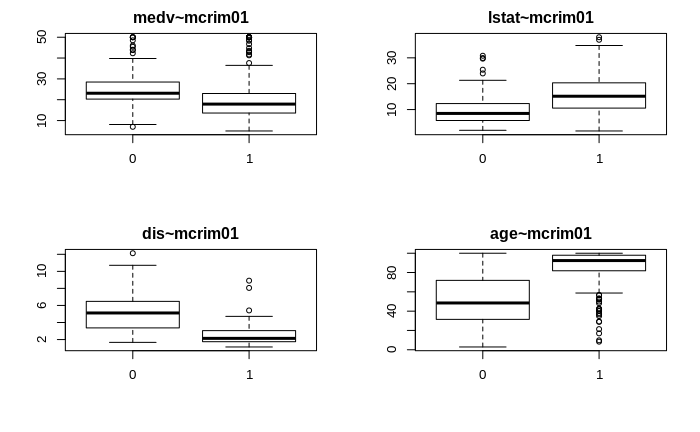

```r
boxplot(dis~mcrim01,Data,main='dis~mcrim01')
boxplot(age~mcrim01,Data,main='age~mcrim01')
```

Interestingly enough, the weighted mean of distance to employment centers has a strong negative correlation with crime.